# Healthy vs. Wasting Analysis

Meghan M. Shea

2026-09-01

# Set Up

### Load Libraries

```r
# Packages used
packages = c("tidyverse", "knitr", "kableExtra")

## Load or install&load
package.check <- lapply(packages,
  FUN = function(x) {
    if (!require(x, character.only = TRUE)) {
      install.packages(x, dependencies = TRUE)
      library(x, character.only = TRUE)
    }
  }
)
```

### Import Data

```r
ddPCR_data <- read.csv("raw_data/ddPCR_raw_data/Stanford/Stanford_22Jan2026_SonomaFieldSamples.csv", stringsAsFactors = FALSE)
```

# Data Cleaning & Quality Control

First, we want to confirm our reaction details

```r
rxn_volume = 20
volume_post_DNA_extraction = 100
template_volume = 5
```

Then, we want to check that our NTC and positive control are as expected and that all samples have generated sufficient (>10000 droplets)

```r
# Check if all NTC samples have concentration of 0
ntc_check <- ddPCR_data %>%
  filter(Sample.Type == "NTC") %>%
  filter(Conc.copies.µL. != 0)

# View any NTC samples that don't have 0 concentration
if (nrow(ntc_check) > 0) {
  print("WARNING: The following NTC samples have non-zero concentrations:")
  print(ntc_check)
} else {
  print("✓ All NTC samples have concentration = 0")
}
```

```
## [1] "✓ All NTC samples have concentration = 0"
```

```r
#Check if positive control sample(s) are close (within 20%) to the expected concentration

# Filter for gBlock samples and extract the number
gblock_check <- ddPCR_data %>%
  filter(grepl("gBlock", Sample.description.1)) %>%
  mutate(
    expected_conc = as.numeric(str_extract(Sample.description.1, "\\d+")),
    adjusted_conc = Conc.copies.µL. * rxn_volume/template_volume,
    percent_diff = abs((adjusted_conc - expected_conc) / expected_conc) * 100,
    within_20pct = percent_diff <= 20
  )

# Display samples that fail the 10% threshold
failing_samples <- gblock_check %>%
  filter(!within_20pct)

if (nrow(failing_samples) > 0) {
  print("WARNING: The following gBlock samples are NOT within 20% of expected concentration:")
  print(failing_samples %>% select(Sample.description.1, expected_conc, adjusted_conc, percent_diff))
} else {
  print("✓ All gBlock samples are within 20% of expected concentration")
}
```

```
## [1] "✓ All gBlock samples are within 20% of expected concentration"
```

```r
# Check if all samples have sufficient (>10000) droplets
low_droplets <- ddPCR_data %>%
  filter(Accepted.Droplets < 10000)

# Display results
if (nrow(low_droplets) > 0) {
  print("WARNING: The following samples have fewer than 10,000 accepted droplets:")
  print(low_droplets)
} else {
  print("✓ All samples have at least 10,000 accepted droplets")
}
```

```
## [1] "✓ All samples have at least 10,000 accepted droplets"
```

Then, we want to convert our ddPCR output in copies per ul into copies per L of water filtered.

```r
ddPCR_data$copies.per.L = (ddPCR_data$Conc.copies.µL. * rxn_volume * (volume_post_DNA_extraction/template_volume))/(ddPCR_data$Volume.Filtered/1000)
```

# Analysis

Now, we want to summarize our data across sample types.

```r
# Filter out PC and NTC samples, then summarize for each combination of sample type & distance
summary_table_1 <- ddPCR_data %>%
  filter(!Sample.Type %in% c("PC", "NTC")) %>%
  group_by(Sample.Type, Distance) %>%
  summarise(
    n = n(),
    mean_copies_per_L = mean(copies.per.L, na.rm = TRUE),
    sd_copies_per_L = sd(copies.per.L, na.rm = TRUE),
    min_copies_per_L = min(copies.per.L, na.rm = TRUE),
    max_copies_per_L = max(copies.per.L, na.rm = TRUE),
    .groups = "drop"
  )

summary_table_1 %>%
  kable(col.names = c("Sample Type", "Distance", "N", "Mean", "SD", "Min", "Max"),
        caption = "eDNA (Copies per L) by Sample Type and Distance",
        digits = 2,
        format.args = list(big.mark = ",")) %>%
  kable_styling(bootstrap_options = c("striped", "hover", "condensed"),
                full_width = FALSE,
                position = "left") %>%
  row_spec(0, bold = TRUE, color = "white", background = "#2C3E50")
```

eDNA (Copies per L) by Sample Type and Distance

| Sample Type | Distance | N | Mean | SD | Min | Max |
| --- | --- | --- | --- | --- | --- | --- |
| Healthy | 0 | 3 | 147.53 | 73.17 | 63.08 | 192.23 |
| Healthy | 50 | 3 | 324.26 | 190.54 | 179.36 | 540.10 |
| Healthy | 100 | 3 | 237.54 | 79.62 | 154.34 | 313.01 |
| Wasting | 0 | 3 | 52,524.04 | 5,853.09 | 45,766.05 | 55,979.52 |
| Wasting | 50 | 3 | 128.75 | 66.54 | 53.74 | 180.68 |

```r
# Summarize across all healthy samples
summary_table_2 <- ddPCR_data %>%
  filter(Sample.Type %in% c("Healthy")) %>%
  summarise(
    n = n(),
    mean_copies_per_L = mean(copies.per.L, na.rm = TRUE),
    sd_copies_per_L = sd(copies.per.L, na.rm = TRUE),
    min_copies_per_L = min(copies.per.L, na.rm = TRUE),
    max_copies_per_L = max(copies.per.L, na.rm = TRUE),
    .groups = "drop"
  )

summary_table_2 %>%
  kable(col.names = c("N", "Mean Copies/L", "SD", "Min", "Max"),
        caption = "eDNA (Copies per L) for All Healthy Samples",
        digits = 2,
        format.args = list(big.mark = ",")) %>%
  kable_styling(bootstrap_options = c("striped", "hover"),
                full_width = FALSE,
                position = "left") %>%
  row_spec(0, bold = TRUE, color = "white", background = "#27AE60")
```

eDNA (Copies per L) for All Healthy Samples

| N | Mean Copies/L | SD | Min | Max |
| --- | --- | --- | --- | --- |
| 9 | 236.44 | 133.63 | 63.08 | 540.1 |

### Limits of Detection and Quantification

We also want to compare our sample concentrations to our calculated limits of detection and quantification. We want to read in our lab’s limits of detection (LOD) and limits of quantification (LOQ), convert them from copies/reaction to copies/L using every filtration volume observed in this data set, and identify the lowest and highest resulting limits.

```r
lod_loq_data <- read.csv("LOD_LOQ/final_lob_lod_loq_table.csv", stringsAsFactors = FALSE)

# Filter to Stanford lab only
stanford_lod_loq <- lod_loq_data %>%
  filter(Lab == "Stanford")

# Get every unique Volume.Filtered value present in ddPCR_data, excluding NA
unique_volumes <- unique(na.omit(ddPCR_data$Volume.Filtered))
smallest_volume <- min(unique_volumes)
largest_volume <- max(unique_volumes)

# Convert LOD and LOQ (copies/reaction) to copies/L, calculated for every
# combination of Stanford LOD/LOQ value and observed filtration volume
lod_loq_converted <- stanford_lod_loq %>%
  crossing(Volume.Filtered = unique_volumes) %>%
  mutate(
    LOD_copies_per_L = LOD * (volume_post_DNA_extraction / template_volume) / (Volume.Filtered / 1000),
    LOQ_copies_per_L = LOQ * (volume_post_DNA_extraction / template_volume) / (Volume.Filtered / 1000),
    volume_label = case_when(
      Volume.Filtered == smallest_volume ~ "smallest sample volume",
      Volume.Filtered == largest_volume ~ "largest sample volume",
      TRUE ~ paste0(Volume.Filtered, " mL sample volume")
    )
  )

# Identify the row corresponding to each of the 4 extreme values
lod_min_row <- lod_loq_converted[which.min(lod_loq_converted$LOD_copies_per_L), ]
lod_max_row <- lod_loq_converted[which.max(lod_loq_converted$LOD_copies_per_L), ]
loq_min_row <- lod_loq_converted[which.min(lod_loq_converted$LOQ_copies_per_L), ]
loq_max_row <- lod_loq_converted[which.max(lod_loq_converted$LOQ_copies_per_L), ]

# Build labeled lines, including method, type, volume, and value detail
lod_loq_lines <- tibble(
  value = c(lod_min_row$LOD_copies_per_L, lod_max_row$LOD_copies_per_L,
            loq_min_row$LOQ_copies_per_L, loq_max_row$LOQ_copies_per_L),
  Limit = c("LOD", "LOD", "LOQ", "LOQ"),
  Bound = c("Min", "Max", "Min", "Max"),
  main_label = c(
    "Smallest Calculated LOD",
    "Largest Calculated LOD",
    "Smallest Calculated LOQ",
    "Largest Calculated LOQ"
  ),
  detail_label = c(
    paste0("(", paste(lod_min_row$LoD_method, lod_min_row$Type, lod_min_row$volume_label, sep = ", "), ")"),
    paste0("(", paste(lod_max_row$LoD_method, lod_max_row$Type, lod_max_row$volume_label, sep = ", "), ")"),
    paste0("(", paste(loq_min_row$LoD_method, loq_min_row$Type, loq_min_row$volume_label, sep = ", "), ")"),
    paste0("(", paste(loq_max_row$LoD_method, loq_max_row$Type, loq_max_row$volume_label, sep = ", "), ")")
  )
) %>%
  mutate(value_line = paste0(main_label, " = ", round(value, 1), " copies/L"))
```

### Figure: eDNA Concentration by Sample Type and Distance

Now, we want to visualize the distribution of eDNA concentration (copies per L) for each sample type, using a box & whisker plot overlaid with individual data points, grouped by sample type and then by distance within each.

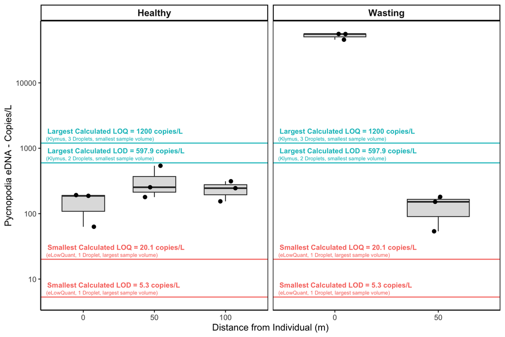

```r
# Exclude PC and NTC samples, which aren't biological sample types
# Ensure Distance is treated as an ordered factor (0, 50, 100) rather than sorted alphabetically/numerically by default
plot_data <- ddPCR_data %>%
  filter(!Sample.Type %in% c("PC", "NTC")) %>%
  mutate(Distance = factor(Distance, levels = c(0, 50, 100)))

ggplot(plot_data, aes(x = Distance, y = copies.per.L)) +
  geom_boxplot(outlier.shape = NA, alpha = 0.5, width = 0.6, fill = "gray") +
  geom_jitter(width = 0.15, height = 0, size = 2, alpha = 1, shape = 21, fill = "black", color = "black") +
  geom_hline(data = lod_loq_lines, aes(yintercept = value, color = Bound), linewidth = 0.6, show.legend = FALSE) +
  geom_text(
    data = lod_loq_lines,
    aes(x = -Inf, y = value, label = value_line, color = Bound),
    hjust = -0.05, vjust = -1.9, size = 3.2, fontface = "bold", show.legend = FALSE
  ) +
  geom_text(
    data = lod_loq_lines,
    aes(x = -Inf, y = value, label = detail_label, color = Bound),
    hjust = -0.05, vjust = -0.7, size = 2.4, show.legend = FALSE
  ) +
  scale_color_manual(values = c(Min = "#F8766D", Max = "#00BFC4")) +
  scale_y_log10() +
  facet_wrap(~ Sample.Type, scales = "free_x") +
  labs(
    x = "Distance from Individual (m)",
    y = "Pycnopodia eDNA - Copies/L"
  ) +
  theme_classic(base_size = 12) +
  theme(
    plot.title = element_text(face = "bold", hjust = 0.5),
    strip.text = element_text(face = "bold", size = 12),
    panel.border = element_rect(color = "black", fill = NA, linewidth = 0.7)
  )
```

```r
ggsave("Figures/Fig_S5_healthy_wasting_concentrations.png",
       width = 7, height = 5, units = "in",
       dpi = 300)
```